# act_report

## Report: act_report

- Create a **250-word-minimum written report** called "act_report.pdf" or "act_report.html" that communicates the insights and displays the visualization(s) produced from your wrangled data. This is to be framed as an external document, like a blog post or magazine article, for example.

#### Introduction

The cleaned WeRateDogs Twitter data prepared for analysis has 2077 rows and 13 columns with which interesting analyses and visualizations were created to communicate insights derived therein.

To ensure engaged attention in the course of insights communication, Python libraries such as matplotlib and seaborn were deployed to generate some catchy visualizations for analysis.

#### Dog Ratings anaylysis

WeRateDogs believes almost all dogs deserve atleast a 10 or sometimes more than that hence the ratings denominator is always 10. so our focus analysis is on the numerator which gives better ratings as equal to or greater than 10 (>=10) and vice versa.

[figure not shown]

#### Relationship: Favorites Retweets and Ratings

Attempt to examine the relationship between Favorites & Retweets, and between Favorites & Ratings through a Correlation plot produced opposite results. While there is a strong positive correlation between Favorites and retweets i.e a linear relationship between the retweet counts and the favorite counts, there is no clear relationship between the favorite count and the ratings.

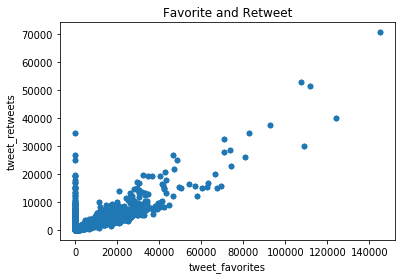

With a correlation coefficient of 92.6%, Favorites and retweets demostrated a strong relationship as shown in the above diagram

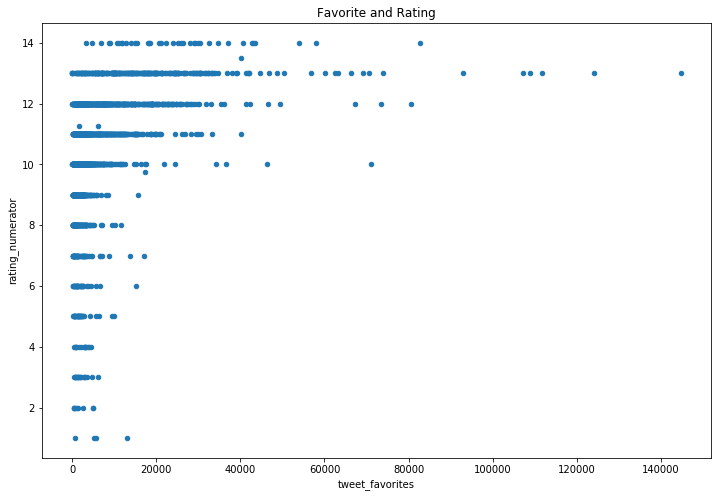

As the above image suggests, Favorite count and ratings have no clear relationship relationship with a correllation coefficient of about 39.6% between them

#### Most Popular Dog Breeds

we attempt to derive insight on the most tweeted dog breeds by, the analysis displayed the Top 10 breed as shown in the image below:

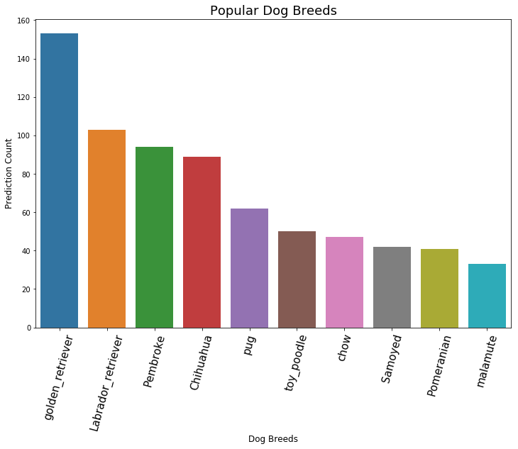

Golden Retriever is the most popular dog breed as it has most tweets on them giving it the lead on the most popular list with Labrador_retriever and Pembroke taking the second and third place respectively.

#### Most Used Tweet Source

looking at the source of tweets anaylysis, iPhone had 1945, Vine had 91, Twitter Web had 31 and TweetDeck had 10. this is represented in the image below:

[figure not shown]

The analysis showed that WeRateDogs tweets had 93.6% of the tweets posted from iPhone making it the most used device by dog owners. This is a critical insight when developers of the twitter interface to ensure that the applications are properly working on iPhone devices.

#### Conclusion

The dataset promises a bunch of meaningful insights that can be generated further than the foregoing analysis and visualization. Hence, this is just a bit of the possible outcome from the wrangling project.

Thank you for reading!